# Risk Factor Analysis

## Outcome Variable

**Outcome Variable:** pers_wast

## Predictor Variables

**Intervention Variable:** birthwt

**Adjustment Set:**

unadjusted

## Stratifying Variables

The analysis was stratified on these variable(s):

- agecat
- studyid
- country

## Data Summary

| agecat | studyid | country | birthwt | pers_wast | n_cell | n |
| --- | --- | --- | --- | --- | --- | --- |
| 0-24 months | CMC-V-BCS-2002 | INDIA | Normal or high birthweight | 0 | 305 | 365 |
| 0-24 months | CMC-V-BCS-2002 | INDIA | Normal or high birthweight | 1 | 17 | 365 |
| 0-24 months | CMC-V-BCS-2002 | INDIA | Low birthweight | 0 | 38 | 365 |
| 0-24 months | CMC-V-BCS-2002 | INDIA | Low birthweight | 1 | 5 | 365 |
| 0-24 months | CMIN | BANGLADESH | Normal or high birthweight | 0 | 9 | 12 |
| 0-24 months | CMIN | BANGLADESH | Normal or high birthweight | 1 | 0 | 12 |
| 0-24 months | CMIN | BANGLADESH | Low birthweight | 0 | 3 | 12 |
| 0-24 months | CMIN | BANGLADESH | Low birthweight | 1 | 0 | 12 |
| 0-24 months | COHORTS | GUATEMALA | Normal or high birthweight | 0 | 706 | 795 |
| 0-24 months | COHORTS | GUATEMALA | Normal or high birthweight | 1 | 17 | 795 |
| 0-24 months | COHORTS | GUATEMALA | Low birthweight | 0 | 69 | 795 |
| 0-24 months | COHORTS | GUATEMALA | Low birthweight | 1 | 3 | 795 |
| 0-24 months | COHORTS | INDIA | Normal or high birthweight | 0 | 3998 | 5268 |
| 0-24 months | COHORTS | INDIA | Normal or high birthweight | 1 | 281 | 5268 |
| 0-24 months | COHORTS | INDIA | Low birthweight | 0 | 763 | 5268 |
| 0-24 months | COHORTS | INDIA | Low birthweight | 1 | 226 | 5268 |
| 0-24 months | COHORTS | PHILIPPINES | Normal or high birthweight | 0 | 2409 | 2768 |
| 0-24 months | COHORTS | PHILIPPINES | Normal or high birthweight | 1 | 106 | 2768 |
| 0-24 months | COHORTS | PHILIPPINES | Low birthweight | 0 | 219 | 2768 |
| 0-24 months | COHORTS | PHILIPPINES | Low birthweight | 1 | 34 | 2768 |
| 0-24 months | CONTENT | PERU | Normal or high birthweight | 0 | 2 | 2 |
| 0-24 months | CONTENT | PERU | Normal or high birthweight | 1 | 0 | 2 |
| 0-24 months | CONTENT | PERU | Low birthweight | 0 | 0 | 2 |
| 0-24 months | CONTENT | PERU | Low birthweight | 1 | 0 | 2 |
| 0-24 months | EE | PAKISTAN | Normal or high birthweight | 0 | 225 | 376 |
| 0-24 months | EE | PAKISTAN | Normal or high birthweight | 1 | 19 | 376 |
| 0-24 months | EE | PAKISTAN | Low birthweight | 0 | 118 | 376 |
| 0-24 months | EE | PAKISTAN | Low birthweight | 1 | 14 | 376 |
| 0-24 months | GMS-Nepal | NEPAL | Normal or high birthweight | 0 | 378 | 596 |
| 0-24 months | GMS-Nepal | NEPAL | Normal or high birthweight | 1 | 40 | 596 |

[output cut: 278 more lines]

The following strata were considered:

- agecat: 0-24 months, studyid: CMC-V-BCS-2002, country: INDIA
- agecat: 0-24 months, studyid: CMIN, country: BANGLADESH
- agecat: 0-24 months, studyid: COHORTS, country: GUATEMALA
- agecat: 0-24 months, studyid: COHORTS, country: INDIA
- agecat: 0-24 months, studyid: COHORTS, country: PHILIPPINES
- agecat: 0-24 months, studyid: CONTENT, country: PERU
- agecat: 0-24 months, studyid: EE, country: PAKISTAN
- agecat: 0-24 months, studyid: GMS-Nepal, country: NEPAL
- agecat: 0-24 months, studyid: IRC, country: INDIA
- agecat: 0-24 months, studyid: JiVitA-3, country: BANGLADESH
- agecat: 0-24 months, studyid: JiVitA-4, country: BANGLADESH
- agecat: 0-24 months, studyid: Keneba, country: GAMBIA
- agecat: 0-24 months, studyid: MAL-ED, country: BANGLADESH
- agecat: 0-24 months, studyid: MAL-ED, country: BRAZIL
- agecat: 0-24 months, studyid: MAL-ED, country: INDIA
- agecat: 0-24 months, studyid: MAL-ED, country: NEPAL
- agecat: 0-24 months, studyid: MAL-ED, country: PERU
- agecat: 0-24 months, studyid: MAL-ED, country: SOUTH AFRICA
- agecat: 0-24 months, studyid: MAL-ED, country: TANZANIA, UNITED REPUBLIC OF
- agecat: 0-24 months, studyid: NIH-Birth, country: BANGLADESH
- agecat: 0-24 months, studyid: NIH-Crypto, country: BANGLADESH
- agecat: 0-24 months, studyid: PROBIT, country: BELARUS
- agecat: 0-24 months, studyid: PROVIDE, country: BANGLADESH
- agecat: 0-24 months, studyid: ResPak, country: PAKISTAN
- agecat: 0-24 months, studyid: SAS-CompFeed, country: INDIA
- agecat: 0-24 months, studyid: TanzaniaChild2, country: TANZANIA, UNITED REPUBLIC OF
- agecat: 0-24 months, studyid: ZVITAMBO, country: ZIMBABWE
- agecat: 0-6 months, studyid: CMC-V-BCS-2002, country: INDIA
- agecat: 0-6 months, studyid: CMIN, country: BANGLADESH
- agecat: 0-6 months, studyid: COHORTS, country: PHILIPPINES
- agecat: 0-6 months, studyid: CONTENT, country: PERU
- agecat: 0-6 months, studyid: EE, country: PAKISTAN
- agecat: 0-6 months, studyid: GMS-Nepal, country: NEPAL
- agecat: 0-6 months, studyid: IRC, country: INDIA
- agecat: 0-6 months, studyid: JiVitA-3, country: BANGLADESH
- agecat: 0-6 months, studyid: Keneba, country: GAMBIA
- agecat: 0-6 months, studyid: MAL-ED, country: BANGLADESH
- agecat: 0-6 months, studyid: MAL-ED, country: BRAZIL
- agecat: 0-6 months, studyid: MAL-ED, country: INDIA
- agecat: 0-6 months, studyid: MAL-ED, country: NEPAL
- agecat: 0-6 months, studyid: MAL-ED, country: PERU
- agecat: 0-6 months, studyid: MAL-ED, country: SOUTH AFRICA
- agecat: 0-6 months, studyid: MAL-ED, country: TANZANIA, UNITED REPUBLIC OF
- agecat: 0-6 months, studyid: NIH-Birth, country: BANGLADESH
- agecat: 0-6 months, studyid: NIH-Crypto, country: BANGLADESH
- agecat: 0-6 months, studyid: PROBIT, country: BELARUS
- agecat: 0-6 months, studyid: PROVIDE, country: BANGLADESH
- agecat: 0-6 months, studyid: ResPak, country: PAKISTAN
- agecat: 0-6 months, studyid: TanzaniaChild2, country: TANZANIA, UNITED REPUBLIC OF
- agecat: 0-6 months, studyid: ZVITAMBO, country: ZIMBABWE
- agecat: 6-24 months, studyid: CMC-V-BCS-2002, country: INDIA
- agecat: 6-24 months, studyid: CMIN, country: BANGLADESH
- agecat: 6-24 months, studyid: COHORTS, country: GUATEMALA
- agecat: 6-24 months, studyid: COHORTS, country: INDIA
- agecat: 6-24 months, studyid: COHORTS, country: PHILIPPINES
- agecat: 6-24 months, studyid: CONTENT, country: PERU
- agecat: 6-24 months, studyid: EE, country: PAKISTAN
- agecat: 6-24 months, studyid: GMS-Nepal, country: NEPAL
- agecat: 6-24 months, studyid: IRC, country: INDIA
- agecat: 6-24 months, studyid: JiVitA-3, country: BANGLADESH
- agecat: 6-24 months, studyid: JiVitA-4, country: BANGLADESH
- agecat: 6-24 months, studyid: Keneba, country: GAMBIA
- agecat: 6-24 months, studyid: MAL-ED, country: BANGLADESH
- agecat: 6-24 months, studyid: MAL-ED, country: BRAZIL
- agecat: 6-24 months, studyid: MAL-ED, country: INDIA
- agecat: 6-24 months, studyid: MAL-ED, country: NEPAL
- agecat: 6-24 months, studyid: MAL-ED, country: PERU
- agecat: 6-24 months, studyid: MAL-ED, country: SOUTH AFRICA
- agecat: 6-24 months, studyid: MAL-ED, country: TANZANIA, UNITED REPUBLIC OF
- agecat: 6-24 months, studyid: NIH-Birth, country: BANGLADESH
- agecat: 6-24 months, studyid: NIH-Crypto, country: BANGLADESH
- agecat: 6-24 months, studyid: PROBIT, country: BELARUS
- agecat: 6-24 months, studyid: PROVIDE, country: BANGLADESH
- agecat: 6-24 months, studyid: ResPak, country: PAKISTAN
- agecat: 6-24 months, studyid: SAS-CompFeed, country: INDIA
- agecat: 6-24 months, studyid: TanzaniaChild2, country: TANZANIA, UNITED REPUBLIC OF
- agecat: 6-24 months, studyid: ZVITAMBO, country: ZIMBABWE

### Dropped Strata

Some strata were dropped due to rare outcomes:

- agecat: 0-24 months, studyid: CMIN, country: BANGLADESH
- agecat: 0-24 months, studyid: COHORTS, country: GUATEMALA
- agecat: 0-24 months, studyid: CONTENT, country: PERU
- agecat: 0-24 months, studyid: MAL-ED, country: BANGLADESH
- agecat: 0-24 months, studyid: MAL-ED, country: BRAZIL
- agecat: 0-24 months, studyid: MAL-ED, country: NEPAL
- agecat: 0-24 months, studyid: MAL-ED, country: PERU
- agecat: 0-24 months, studyid: MAL-ED, country: SOUTH AFRICA
- agecat: 0-24 months, studyid: MAL-ED, country: TANZANIA, UNITED REPUBLIC OF
- agecat: 0-24 months, studyid: PROBIT, country: BELARUS
- agecat: 0-24 months, studyid: ResPak, country: PAKISTAN
- agecat: 0-6 months, studyid: CMIN, country: BANGLADESH
- agecat: 0-6 months, studyid: CONTENT, country: PERU
- agecat: 0-6 months, studyid: JiVitA-3, country: BANGLADESH
- agecat: 0-6 months, studyid: MAL-ED, country: BANGLADESH
- agecat: 0-6 months, studyid: MAL-ED, country: BRAZIL
- agecat: 0-6 months, studyid: MAL-ED, country: NEPAL
- agecat: 0-6 months, studyid: MAL-ED, country: PERU
- agecat: 0-6 months, studyid: MAL-ED, country: SOUTH AFRICA
- agecat: 0-6 months, studyid: MAL-ED, country: TANZANIA, UNITED REPUBLIC OF
- agecat: 0-6 months, studyid: NIH-Birth, country: BANGLADESH
- agecat: 0-6 months, studyid: NIH-Crypto, country: BANGLADESH
- agecat: 0-6 months, studyid: PROBIT, country: BELARUS
- agecat: 0-6 months, studyid: ResPak, country: PAKISTAN
- agecat: 0-6 months, studyid: ZVITAMBO, country: ZIMBABWE
- agecat: 6-24 months, studyid: CMIN, country: BANGLADESH
- agecat: 6-24 months, studyid: COHORTS, country: GUATEMALA
- agecat: 6-24 months, studyid: CONTENT, country: PERU
- agecat: 6-24 months, studyid: MAL-ED, country: BANGLADESH
- agecat: 6-24 months, studyid: MAL-ED, country: BRAZIL
- agecat: 6-24 months, studyid: MAL-ED, country: NEPAL
- agecat: 6-24 months, studyid: MAL-ED, country: PERU
- agecat: 6-24 months, studyid: MAL-ED, country: SOUTH AFRICA
- agecat: 6-24 months, studyid: MAL-ED, country: TANZANIA, UNITED REPUBLIC OF
- agecat: 6-24 months, studyid: PROBIT, country: BELARUS
- agecat: 6-24 months, studyid: ResPak, country: PAKISTAN

## Methods Detail

We’re interested in the causal parameters $E[Y_a]$ for all values of $a \in \mathcal{A}$. These parameters represent the mean outcome if, possibly contrary to fact, we intervened to set all units to have $A=a$. Under the randomization and positivity assumptions, these are identified by the statistical parameters $\psi_a=E_W[E_{Y|A,W}(Y|A=a,W)]$. In addition, we’re interested in the mean of $Y$, $E[Y]$ under no intervention (the observed mean). We will estimate these parameters by using SuperLearner to fit the relevant likelihood factors – $E_{Y|A,W}(Y|A=a,W)$ and $p(A=a|W)$, and then updating our likelihood fit using a joint TMLE.

For unadjusted analyses ($W=\{\}$), initial likelihoods were estimated using Lrnr_glm to estimate the simple $E(Y|A)$ and Lrnr_mean to estimate $p(A)$. For adjusted analyses, a small library containing Lrnr_glmnet, Lrnr_xgboost, and Lrnr_mean was used.

Having estimated these parameters, we will then use the delta method to estimate relative risks and attributable risks relative to a prespecified baseline level of $A$.

# Results Detail

## Results Plots

[figure not shown]

[figure not shown]

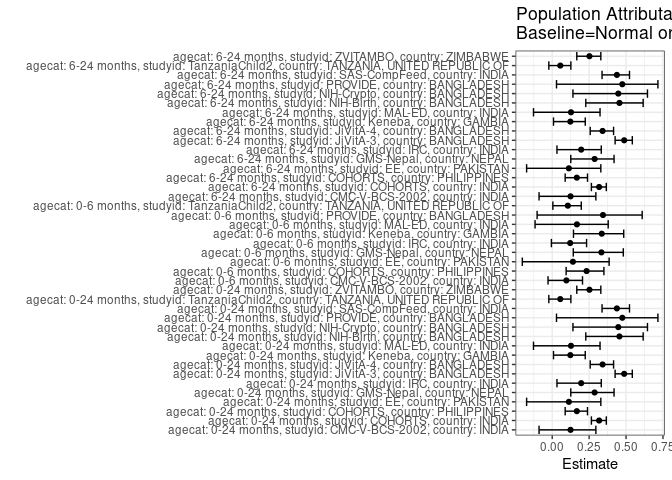

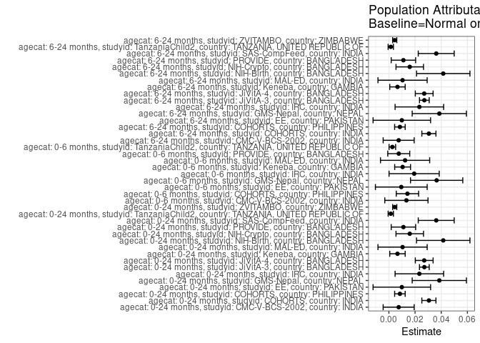

## Results Table

### Parameter: TSM

| agecat | studyid | country | intervention_level | baseline_level | estimate | ci_lower | ci_upper |
| --- | --- | --- | --- | --- | --- | --- | --- |
| 0-24 months | CMC-V-BCS-2002 | INDIA | Normal or high birthweight | NA | 0.0527950 | 0.0283363 | 0.0772538 |
| 0-24 months | CMC-V-BCS-2002 | INDIA | Low birthweight | NA | 0.1162791 | 0.0203350 | 0.2122231 |
| 0-24 months | COHORTS | INDIA | Normal or high birthweight | NA | 0.0656695 | 0.0582470 | 0.0730921 |
| 0-24 months | COHORTS | INDIA | Low birthweight | NA | 0.2285137 | 0.2023432 | 0.2546841 |
| 0-24 months | COHORTS | PHILIPPINES | Normal or high birthweight | NA | 0.0421471 | 0.0342931 | 0.0500011 |
| 0-24 months | COHORTS | PHILIPPINES | Low birthweight | NA | 0.1343874 | 0.0923527 | 0.1764220 |
| 0-24 months | EE | PAKISTAN | Normal or high birthweight | NA | 0.0778689 | 0.0442014 | 0.1115363 |
| 0-24 months | EE | PAKISTAN | Low birthweight | NA | 0.1060606 | 0.0534625 | 0.1586588 |
| 0-24 months | GMS-Nepal | NEPAL | Normal or high birthweight | NA | 0.0956938 | 0.0674694 | 0.1239181 |
| 0-24 months | GMS-Nepal | NEPAL | Low birthweight | NA | 0.2247191 | 0.1633496 | 0.2860886 |
| 0-24 months | IRC | INDIA | Normal or high birthweight | NA | 0.0955224 | 0.0640075 | 0.1270372 |
| 0-24 months | IRC | INDIA | Low birthweight | NA | 0.2318841 | 0.1321805 | 0.3315876 |
| 0-24 months | JiVitA-3 | BANGLADESH | Normal or high birthweight | NA | 0.0285164 | 0.0244490 | 0.0325838 |
| 0-24 months | JiVitA-3 | BANGLADESH | Low birthweight | NA | 0.0996483 | 0.0906612 | 0.1086354 |
| 0-24 months | JiVitA-4 | BANGLADESH | Normal or high birthweight | NA | 0.0521500 | 0.0432058 | 0.0610943 |
| 0-24 months | JiVitA-4 | BANGLADESH | Low birthweight | NA | 0.1557093 | 0.1319515 | 0.1794672 |
| 0-24 months | Keneba | GAMBIA | Normal or high birthweight | NA | 0.0469116 | 0.0353195 | 0.0585038 |
| 0-24 months | Keneba | GAMBIA | Low birthweight | NA | 0.0921659 | 0.0536667 | 0.1306651 |
| 0-24 months | MAL-ED | INDIA | Normal or high birthweight | NA | 0.0717949 | 0.0354836 | 0.1081062 |
| 0-24 months | MAL-ED | INDIA | Low birthweight | NA | 0.1388889 | 0.0256743 | 0.2521034 |
| 0-24 months | NIH-Birth | BANGLADESH | Normal or high birthweight | NA | 0.0497238 | 0.0273096 | 0.0721379 |
| 0-24 months | NIH-Birth | BANGLADESH | Low birthweight | NA | 0.1895425 | 0.1273779 | 0.2517070 |
| 0-24 months | NIH-Crypto | BANGLADESH | Normal or high birthweight | NA | 0.0196780 | 0.0081563 | 0.0311996 |
| 0-24 months | NIH-Crypto | BANGLADESH | Low birthweight | NA | 0.0877193 | 0.0452906 | 0.1301480 |
| 0-24 months | PROVIDE | BANGLADESH | Normal or high birthweight | NA | 0.0122951 | 0.0025102 | 0.0220800 |
| 0-24 months | PROVIDE | BANGLADESH | Low birthweight | NA | 0.0588235 | 0.0215112 | 0.0961359 |
| 0-24 months | SAS-CompFeed | INDIA | Normal or high birthweight | NA | 0.0464217 | 0.0316426 | 0.0612007 |
| 0-24 months | SAS-CompFeed | INDIA | Low birthweight | NA | 0.1987578 | 0.1361692 | 0.2613463 |
| 0-24 months | TanzaniaChild2 | TANZANIA, UNITED REPUBLIC OF | Normal or high birthweight | NA | 0.0251451 | 0.0183956 | 0.0318946 |
| 0-24 months | TanzaniaChild2 | TANZANIA, UNITED REPUBLIC OF | Low birthweight | NA | 0.0666667 | 0.0102001 | 0.1231333 |

[output cut: 52 more lines]

### Parameter: E(Y)

| agecat | studyid | country | intervention_level | baseline_level | estimate | ci_lower | ci_upper |
| --- | --- | --- | --- | --- | --- | --- | --- |
| 0-24 months | CMC-V-BCS-2002 | INDIA | NA | NA | 0.0602740 | 0.0358249 | 0.0847231 |
| 0-24 months | COHORTS | INDIA | NA | NA | 0.0962415 | 0.0882767 | 0.1042062 |
| 0-24 months | COHORTS | PHILIPPINES | NA | NA | 0.0505780 | 0.0424131 | 0.0587430 |
| 0-24 months | EE | PAKISTAN | NA | NA | 0.0877660 | 0.0591276 | 0.1164044 |
| 0-24 months | GMS-Nepal | NEPAL | NA | NA | 0.1342282 | 0.1068369 | 0.1616195 |
| 0-24 months | IRC | INDIA | NA | NA | 0.1188119 | 0.0872211 | 0.1504026 |
| 0-24 months | JiVitA-3 | BANGLADESH | NA | NA | 0.0556259 | 0.0512873 | 0.0599644 |
| 0-24 months | JiVitA-4 | BANGLADESH | NA | NA | 0.0791432 | 0.0700117 | 0.0882747 |
| 0-24 months | Keneba | GAMBIA | NA | NA | 0.0534759 | 0.0420715 | 0.0648803 |
| 0-24 months | MAL-ED | INDIA | NA | NA | 0.0822511 | 0.0467438 | 0.1177583 |
| 0-24 months | NIH-Birth | BANGLADESH | NA | NA | 0.0912621 | 0.0663660 | 0.1161582 |
| 0-24 months | NIH-Crypto | BANGLADESH | NA | NA | 0.0356164 | 0.0221630 | 0.0490699 |
| 0-24 months | PROVIDE | BANGLADESH | NA | NA | 0.0234009 | 0.0116889 | 0.0351130 |
| 0-24 months | SAS-CompFeed | INDIA | NA | NA | 0.0825959 | 0.0584656 | 0.1067261 |
| 0-24 months | TanzaniaChild2 | TANZANIA, UNITED REPUBLIC OF | NA | NA | 0.0265982 | 0.0197841 | 0.0334124 |
| 0-24 months | ZVITAMBO | ZIMBABWE | NA | NA | 0.0176823 | 0.0150321 | 0.0203326 |
| 0-6 months | CMC-V-BCS-2002 | INDIA | NA | NA | 0.1396011 | 0.1032926 | 0.1759097 |
| 0-6 months | COHORTS | PHILIPPINES | NA | NA | 0.0609613 | 0.0448957 | 0.0770269 |
| 0-6 months | EE | PAKISTAN | NA | NA | 0.0675676 | 0.0419574 | 0.0931778 |
| 0-6 months | GMS-Nepal | NEPAL | NA | NA | 0.1095406 | 0.0837882 | 0.1352931 |
| 0-6 months | IRC | INDIA | NA | NA | 0.1586902 | 0.1227025 | 0.1946778 |
| 0-6 months | Keneba | GAMBIA | NA | NA | 0.0312945 | 0.0221903 | 0.0403986 |
| 0-6 months | MAL-ED | INDIA | NA | NA | 0.0739130 | 0.0400273 | 0.1077988 |
| 0-6 months | PROVIDE | BANGLADESH | NA | NA | 0.0219436 | 0.0105669 | 0.0333202 |
| 0-6 months | TanzaniaChild2 | TANZANIA, UNITED REPUBLIC OF | NA | NA | 0.0250000 | 0.0182234 | 0.0317766 |
| 6-24 months | CMC-V-BCS-2002 | INDIA | NA | NA | 0.0602740 | 0.0358249 | 0.0847231 |
| 6-24 months | COHORTS | INDIA | NA | NA | 0.0962415 | 0.0882767 | 0.1042062 |
| 6-24 months | COHORTS | PHILIPPINES | NA | NA | 0.0505780 | 0.0424131 | 0.0587430 |
| 6-24 months | EE | PAKISTAN | NA | NA | 0.0877660 | 0.0591276 | 0.1164044 |
| 6-24 months | GMS-Nepal | NEPAL | NA | NA | 0.1342282 | 0.1068369 | 0.1616195 |
| 6-24 months | IRC | INDIA | NA | NA | 0.1188119 | 0.0872211 | 0.1504026 |
| 6-24 months | JiVitA-3 | BANGLADESH | NA | NA | 0.0556259 | 0.0512873 | 0.0599644 |
| 6-24 months | JiVitA-4 | BANGLADESH | NA | NA | 0.0791432 | 0.0700117 | 0.0882747 |
| 6-24 months | Keneba | GAMBIA | NA | NA | 0.0534759 | 0.0420715 | 0.0648803 |
| 6-24 months | MAL-ED | INDIA | NA | NA | 0.0822511 | 0.0467438 | 0.1177583 |
| 6-24 months | NIH-Birth | BANGLADESH | NA | NA | 0.0912621 | 0.0663660 | 0.1161582 |
| 6-24 months | NIH-Crypto | BANGLADESH | NA | NA | 0.0356164 | 0.0221630 | 0.0490699 |
| 6-24 months | PROVIDE | BANGLADESH | NA | NA | 0.0234009 | 0.0116889 | 0.0351130 |
| 6-24 months | SAS-CompFeed | INDIA | NA | NA | 0.0825959 | 0.0584656 | 0.1067261 |
| 6-24 months | TanzaniaChild2 | TANZANIA, UNITED REPUBLIC OF | NA | NA | 0.0265982 | 0.0197841 | 0.0334124 |
| 6-24 months | ZVITAMBO | ZIMBABWE | NA | NA | 0.0176823 | 0.0150321 | 0.0203326 |

### Parameter: RR

| agecat | studyid | country | intervention_level | baseline_level | estimate | ci_lower | ci_upper |
| --- | --- | --- | --- | --- | --- | --- | --- |
| 0-24 months | CMC-V-BCS-2002 | INDIA | Normal or high birthweight | Normal or high birthweight | 1.000000 | 1.0000000 | 1.000000 |
| 0-24 months | CMC-V-BCS-2002 | INDIA | Low birthweight | Normal or high birthweight | 2.202462 | 0.8549566 | 5.673786 |
| 0-24 months | COHORTS | INDIA | Normal or high birthweight | Normal or high birthweight | 1.000000 | 1.0000000 | 1.000000 |
| 0-24 months | COHORTS | INDIA | Low birthweight | Normal or high birthweight | 3.479751 | 2.9625578 | 4.087233 |
| 0-24 months | COHORTS | PHILIPPINES | Normal or high birthweight | Normal or high birthweight | 1.000000 | 1.0000000 | 1.000000 |
| 0-24 months | COHORTS | PHILIPPINES | Low birthweight | Normal or high birthweight | 3.188530 | 2.2154834 | 4.588942 |
| 0-24 months | EE | PAKISTAN | Normal or high birthweight | Normal or high birthweight | 1.000000 | 1.0000000 | 1.000000 |
| 0-24 months | EE | PAKISTAN | Low birthweight | Normal or high birthweight | 1.362041 | 0.7054286 | 2.629829 |
| 0-24 months | GMS-Nepal | NEPAL | Normal or high birthweight | Normal or high birthweight | 1.000000 | 1.0000000 | 1.000000 |
| 0-24 months | GMS-Nepal | NEPAL | Low birthweight | Normal or high birthweight | 2.348315 | 1.5710384 | 3.510151 |
| 0-24 months | IRC | INDIA | Normal or high birthweight | Normal or high birthweight | 1.000000 | 1.0000000 | 1.000000 |
| 0-24 months | IRC | INDIA | Low birthweight | Normal or high birthweight | 2.427536 | 1.4118689 | 4.173852 |
| 0-24 months | JiVitA-3 | BANGLADESH | Normal or high birthweight | Normal or high birthweight | 1.000000 | 1.0000000 | 1.000000 |
| 0-24 months | JiVitA-3 | BANGLADESH | Low birthweight | Normal or high birthweight | 3.494418 | 2.9600433 | 4.125263 |
| 0-24 months | JiVitA-4 | BANGLADESH | Normal or high birthweight | Normal or high birthweight | 1.000000 | 1.0000000 | 1.000000 |
| 0-24 months | JiVitA-4 | BANGLADESH | Low birthweight | Normal or high birthweight | 2.985795 | 2.3730499 | 3.756757 |
| 0-24 months | Keneba | GAMBIA | Normal or high birthweight | Normal or high birthweight | 1.000000 | 1.0000000 | 1.000000 |
| 0-24 months | Keneba | GAMBIA | Low birthweight | Normal or high birthweight | 1.964670 | 1.2092383 | 3.192032 |
| 0-24 months | MAL-ED | INDIA | Normal or high birthweight | Normal or high birthweight | 1.000000 | 1.0000000 | 1.000000 |
| 0-24 months | MAL-ED | INDIA | Low birthweight | Normal or high birthweight | 1.934524 | 0.7412333 | 5.048859 |
| 0-24 months | NIH-Birth | BANGLADESH | Normal or high birthweight | Normal or high birthweight | 1.000000 | 1.0000000 | 1.000000 |
| 0-24 months | NIH-Birth | BANGLADESH | Low birthweight | Normal or high birthweight | 3.811910 | 2.1829334 | 6.656482 |
| 0-24 months | NIH-Crypto | BANGLADESH | Normal or high birthweight | Normal or high birthweight | 1.000000 | 1.0000000 | 1.000000 |
| 0-24 months | NIH-Crypto | BANGLADESH | Low birthweight | Normal or high birthweight | 4.457735 | 2.0858664 | 9.526690 |
| 0-24 months | PROVIDE | BANGLADESH | Normal or high birthweight | Normal or high birthweight | 1.000000 | 1.0000000 | 1.000000 |
| 0-24 months | PROVIDE | BANGLADESH | Low birthweight | Normal or high birthweight | 4.784314 | 1.7291761 | 13.237320 |
| 0-24 months | SAS-CompFeed | INDIA | Normal or high birthweight | Normal or high birthweight | 1.000000 | 1.0000000 | 1.000000 |
| 0-24 months | SAS-CompFeed | INDIA | Low birthweight | Normal or high birthweight | 4.281574 | 3.2895961 | 5.572682 |
| 0-24 months | TanzaniaChild2 | TANZANIA, UNITED REPUBLIC OF | Normal or high birthweight | Normal or high birthweight | 1.000000 | 1.0000000 | 1.000000 |
| 0-24 months | TanzaniaChild2 | TANZANIA, UNITED REPUBLIC OF | Low birthweight | Normal or high birthweight | 2.651282 | 1.0903832 | 6.446630 |

[output cut: 52 more lines]

### Parameter: PAR

| agecat | studyid | country | intervention_level | baseline_level | estimate | ci_lower | ci_upper |
| --- | --- | --- | --- | --- | --- | --- | --- |
| 0-24 months | CMC-V-BCS-2002 | INDIA | Normal or high birthweight | NA | 0.0074789 | -0.0043735 | 0.0193314 |
| 0-24 months | COHORTS | INDIA | Normal or high birthweight | NA | 0.0305719 | 0.0251839 | 0.0359599 |
| 0-24 months | COHORTS | PHILIPPINES | Normal or high birthweight | NA | 0.0084309 | 0.0043989 | 0.0124630 |
| 0-24 months | EE | PAKISTAN | Normal or high birthweight | NA | 0.0098971 | -0.0120693 | 0.0318635 |
| 0-24 months | GMS-Nepal | NEPAL | Normal or high birthweight | NA | 0.0385344 | 0.0178100 | 0.0592588 |
| 0-24 months | IRC | INDIA | Normal or high birthweight | NA | 0.0232895 | 0.0047410 | 0.0418380 |
| 0-24 months | JiVitA-3 | BANGLADESH | Normal or high birthweight | NA | 0.0271095 | 0.0233947 | 0.0308243 |
| 0-24 months | JiVitA-4 | BANGLADESH | Normal or high birthweight | NA | 0.0269931 | 0.0201900 | 0.0337962 |
| 0-24 months | Keneba | GAMBIA | Normal or high birthweight | NA | 0.0065643 | 0.0006765 | 0.0124521 |
| 0-24 months | MAL-ED | INDIA | Normal or high birthweight | NA | 0.0104562 | -0.0083379 | 0.0292503 |
| 0-24 months | NIH-Birth | BANGLADESH | Normal or high birthweight | NA | 0.0415384 | 0.0211440 | 0.0619328 |
| 0-24 months | NIH-Crypto | BANGLADESH | Normal or high birthweight | NA | 0.0159384 | 0.0054294 | 0.0264475 |
| 0-24 months | PROVIDE | BANGLADESH | Normal or high birthweight | NA | 0.0111059 | 0.0017713 | 0.0204404 |
| 0-24 months | SAS-CompFeed | INDIA | Normal or high birthweight | NA | 0.0361742 | 0.0224388 | 0.0499096 |
| 0-24 months | TanzaniaChild2 | TANZANIA, UNITED REPUBLIC OF | Normal or high birthweight | NA | 0.0014532 | -0.0005632 | 0.0034695 |
| 0-24 months | ZVITAMBO | ZIMBABWE | Normal or high birthweight | NA | 0.0044580 | 0.0028777 | 0.0060383 |
| 0-6 months | CMC-V-BCS-2002 | INDIA | Normal or high birthweight | NA | 0.0133875 | -0.0031171 | 0.0298922 |
| 0-6 months | COHORTS | PHILIPPINES | Normal or high birthweight | NA | 0.0141851 | 0.0056514 | 0.0227188 |
| 0-6 months | EE | PAKISTAN | Normal or high birthweight | NA | 0.0094763 | -0.0103015 | 0.0292540 |
| 0-6 months | GMS-Nepal | NEPAL | Normal or high birthweight | NA | 0.0364928 | 0.0165230 | 0.0564625 |
| 0-6 months | IRC | INDIA | Normal or high birthweight | NA | 0.0192962 | 0.0001218 | 0.0384707 |
| 0-6 months | Keneba | GAMBIA | Normal or high birthweight | NA | 0.0104958 | 0.0044417 | 0.0165499 |
| 0-6 months | MAL-ED | INDIA | Normal or high birthweight | NA | 0.0123746 | -0.0064230 | 0.0311721 |
| 0-6 months | PROVIDE | BANGLADESH | Normal or high birthweight | NA | 0.0075403 | -0.0008617 | 0.0159423 |
| 0-6 months | TanzaniaChild2 | TANZANIA, UNITED REPUBLIC OF | Normal or high birthweight | NA | 0.0026423 | 0.0001425 | 0.0051420 |
| 6-24 months | CMC-V-BCS-2002 | INDIA | Normal or high birthweight | NA | 0.0074789 | -0.0043735 | 0.0193314 |
| 6-24 months | COHORTS | INDIA | Normal or high birthweight | NA | 0.0305719 | 0.0251839 | 0.0359599 |
| 6-24 months | COHORTS | PHILIPPINES | Normal or high birthweight | NA | 0.0084309 | 0.0043989 | 0.0124630 |
| 6-24 months | EE | PAKISTAN | Normal or high birthweight | NA | 0.0098971 | -0.0120693 | 0.0318635 |
| 6-24 months | GMS-Nepal | NEPAL | Normal or high birthweight | NA | 0.0385344 | 0.0178100 | 0.0592588 |
| 6-24 months | IRC | INDIA | Normal or high birthweight | NA | 0.0232895 | 0.0047410 | 0.0418380 |
| 6-24 months | JiVitA-3 | BANGLADESH | Normal or high birthweight | NA | 0.0271095 | 0.0233947 | 0.0308243 |
| 6-24 months | JiVitA-4 | BANGLADESH | Normal or high birthweight | NA | 0.0269931 | 0.0201900 | 0.0337962 |
| 6-24 months | Keneba | GAMBIA | Normal or high birthweight | NA | 0.0065643 | 0.0006765 | 0.0124521 |
| 6-24 months | MAL-ED | INDIA | Normal or high birthweight | NA | 0.0104562 | -0.0083379 | 0.0292503 |
| 6-24 months | NIH-Birth | BANGLADESH | Normal or high birthweight | NA | 0.0415384 | 0.0211440 | 0.0619328 |
| 6-24 months | NIH-Crypto | BANGLADESH | Normal or high birthweight | NA | 0.0159384 | 0.0054294 | 0.0264475 |
| 6-24 months | PROVIDE | BANGLADESH | Normal or high birthweight | NA | 0.0111059 | 0.0017713 | 0.0204404 |
| 6-24 months | SAS-CompFeed | INDIA | Normal or high birthweight | NA | 0.0361742 | 0.0224388 | 0.0499096 |
| 6-24 months | TanzaniaChild2 | TANZANIA, UNITED REPUBLIC OF | Normal or high birthweight | NA | 0.0014532 | -0.0005632 | 0.0034695 |
| 6-24 months | ZVITAMBO | ZIMBABWE | Normal or high birthweight | NA | 0.0044580 | 0.0028777 | 0.0060383 |

### Parameter: PAF

| agecat | studyid | country | intervention_level | baseline_level | estimate | ci_lower | ci_upper |
| --- | --- | --- | --- | --- | --- | --- | --- |
| 0-24 months | CMC-V-BCS-2002 | INDIA | Normal or high birthweight | NA | 0.1240824 | -0.0891428 | 0.2955638 |
| 0-24 months | COHORTS | INDIA | Normal or high birthweight | NA | 0.3176584 | 0.2653143 | 0.3662732 |
| 0-24 months | COHORTS | PHILIPPINES | Normal or high birthweight | NA | 0.1666913 | 0.0877005 | 0.2388427 |
| 0-24 months | EE | PAKISTAN | Normal or high birthweight | NA | 0.1127670 | -0.1734017 | 0.3291450 |
| 0-24 months | GMS-Nepal | NEPAL | Normal or high birthweight | NA | 0.2870813 | 0.1256919 | 0.4186797 |
| 0-24 months | IRC | INDIA | Normal or high birthweight | NA | 0.1960199 | 0.0321423 | 0.3321498 |
| 0-24 months | JiVitA-3 | BANGLADESH | Normal or high birthweight | NA | 0.4873533 | 0.4258661 | 0.5422556 |
| 0-24 months | JiVitA-4 | BANGLADESH | Normal or high birthweight | NA | 0.3410671 | 0.2571920 | 0.4154713 |
| 0-24 months | Keneba | GAMBIA | Normal or high birthweight | NA | 0.1227522 | 0.0086578 | 0.2237153 |
| 0-24 months | MAL-ED | INDIA | Normal or high birthweight | NA | 0.1271255 | -0.1267794 | 0.3238163 |
| 0-24 months | NIH-Birth | BANGLADESH | Normal or high birthweight | NA | 0.4551546 | 0.2274075 | 0.6157657 |
| 0-24 months | NIH-Crypto | BANGLADESH | Normal or high birthweight | NA | 0.4475024 | 0.1403579 | 0.6449062 |
| 0-24 months | PROVIDE | BANGLADESH | Normal or high birthweight | NA | 0.4745902 | 0.0290084 | 0.7156973 |
| 0-24 months | SAS-CompFeed | INDIA | Normal or high birthweight | NA | 0.4379663 | 0.3374210 | 0.5232540 |
| 0-24 months | TanzaniaChild2 | TANZANIA, UNITED REPUBLIC OF | Normal or high birthweight | NA | 0.0546337 | -0.0229578 | 0.1263399 |
| 0-24 months | ZVITAMBO | ZIMBABWE | Normal or high birthweight | NA | 0.2521168 | 0.1663130 | 0.3290895 |
| 0-6 months | CMC-V-BCS-2002 | INDIA | Normal or high birthweight | NA | 0.0958986 | -0.0282734 | 0.2050758 |
| 0-6 months | COHORTS | PHILIPPINES | Normal or high birthweight | NA | 0.2326899 | 0.0941985 | 0.3500068 |
| 0-6 months | EE | PAKISTAN | Normal or high birthweight | NA | 0.1402490 | -0.2024925 | 0.3853002 |
| 0-6 months | GMS-Nepal | NEPAL | Normal or high birthweight | NA | 0.3331437 | 0.1425341 | 0.4813820 |
| 0-6 months | IRC | INDIA | Normal or high birthweight | NA | 0.1215969 | -0.0055049 | 0.2326323 |
| 0-6 months | Keneba | GAMBIA | Normal or high birthweight | NA | 0.3353880 | 0.1439006 | 0.4840446 |
| 0-6 months | MAL-ED | INDIA | Normal or high birthweight | NA | 0.1674208 | -0.1161918 | 0.3789704 |
| 0-6 months | PROVIDE | BANGLADESH | Normal or high birthweight | NA | 0.3436214 | -0.1023367 | 0.6091640 |
| 0-6 months | TanzaniaChild2 | TANZANIA, UNITED REPUBLIC OF | Normal or high birthweight | NA | 0.1056911 | 0.0043545 | 0.1967136 |
| 6-24 months | CMC-V-BCS-2002 | INDIA | Normal or high birthweight | NA | 0.1240824 | -0.0891428 | 0.2955638 |
| 6-24 months | COHORTS | INDIA | Normal or high birthweight | NA | 0.3176584 | 0.2653143 | 0.3662732 |
| 6-24 months | COHORTS | PHILIPPINES | Normal or high birthweight | NA | 0.1666913 | 0.0877005 | 0.2388427 |
| 6-24 months | EE | PAKISTAN | Normal or high birthweight | NA | 0.1127670 | -0.1734017 | 0.3291450 |
| 6-24 months | GMS-Nepal | NEPAL | Normal or high birthweight | NA | 0.2870813 | 0.1256919 | 0.4186797 |
| 6-24 months | IRC | INDIA | Normal or high birthweight | NA | 0.1960199 | 0.0321423 | 0.3321498 |
| 6-24 months | JiVitA-3 | BANGLADESH | Normal or high birthweight | NA | 0.4873533 | 0.4258661 | 0.5422556 |
| 6-24 months | JiVitA-4 | BANGLADESH | Normal or high birthweight | NA | 0.3410671 | 0.2571920 | 0.4154713 |
| 6-24 months | Keneba | GAMBIA | Normal or high birthweight | NA | 0.1227522 | 0.0086578 | 0.2237153 |
| 6-24 months | MAL-ED | INDIA | Normal or high birthweight | NA | 0.1271255 | -0.1267794 | 0.3238163 |
| 6-24 months | NIH-Birth | BANGLADESH | Normal or high birthweight | NA | 0.4551546 | 0.2274075 | 0.6157657 |
| 6-24 months | NIH-Crypto | BANGLADESH | Normal or high birthweight | NA | 0.4475024 | 0.1403579 | 0.6449062 |
| 6-24 months | PROVIDE | BANGLADESH | Normal or high birthweight | NA | 0.4745902 | 0.0290084 | 0.7156973 |
| 6-24 months | SAS-CompFeed | INDIA | Normal or high birthweight | NA | 0.4379663 | 0.3374210 | 0.5232540 |
| 6-24 months | TanzaniaChild2 | TANZANIA, UNITED REPUBLIC OF | Normal or high birthweight | NA | 0.0546337 | -0.0229578 | 0.1263399 |
| 6-24 months | ZVITAMBO | ZIMBABWE | Normal or high birthweight | NA | 0.2521168 | 0.1663130 | 0.3290895 |